# Beda Hingga

Diberikan fungsi $f$, tentukan $\displaystyle{\frac{d^n f(x)}{dx^n}}$.

## Turunan Fungsi

Di dunia nyata, seringkali menghitung turunan diperlukan dalam rentang waktu yang singkat, meskipun harus mengorbankan akurasi. Ingat bahwa turunan pertama mewakili tren dan turunan kedua mewakili kecepatan tren berubah. Di kondisi yang lain, kita juga sering menemukan bahwa kita membutuhkan turunan, namun poin data yang dipunyai tidak banyak. Hanya titik per titik, sementara untuk melakukan *interpolasi* maupun *curve fitting* memakan *resource* yang lebih banyak.

## Turunan Fungsi

Ini mengakibatkan dibutuhkannya suatu konsep untuk menghitung fungsi dengan cepat.

## Turunan Fungsi

Ingat bahwa dari definisi turunan, kita punya

$$ f'(x) = \lim \limits_{x \to 0} \frac{f(x+h) - f(x)}{h} $$

Jika kita mengambil nilai $h$ tertentu, kita akan dapatkan $f'(x)$ mendekati nilai pada ruas kanan (tanpa limit).

## Turunan Fungsi

Sehingga kita bisa tulis ulang menjadi

$$ f'(x) \approx \frac{f(x+h) - f(x)}{h}. $$

## Beda Hingga

Beda hingga atau *finite difference* memiliki tiga metode.

- Beda maju
- Beda mundur
- Beda tengah

## Beda Hingga

Dari persamaan sebelumnya $f'(x) \approx \frac{f(x+h) - f(x)}{h}$, kita bisa memilih nilai $h>0$. Ini menjadi metode beda maju.

$$ f'(x) = \frac{f(x+h) - f(x)}{h}.$$

## Beda Hingga

$$ f'(x) = \frac{f(x - k) - f(x)}{-k} = \frac{f(x) - f(x-k)}{k}$$

atau cukup ditulis $$ f'(x) = \frac{f(x) - f(x-k)}{k}.$$

## Beda Hingga

Kalau kita ganti simbol $k$ dengan $h$ didapat metode beda mundur.

$$ f'(x) = \frac{f(x) - f(x-h)}{h}.$$

*Catatan: Kita juga bisa mendapatkan hasil ini dari pendekatan deret Taylor.*

## Beda Hingga

Untuk beda tengah agak berbeda. Kalau beda maju adalah melakukan aproksimasi maju satu step (satu $h$) dan beda mundur melakukan satu step ke belakang, kalau beda tengah ini melakukan aproksimasi dengan maju setengah step dan mundur setengah step. Ini didapat dengan menggabungkan beda maju dan beda mundur.

$$ f'(x) = \frac12 \left( \frac{f(x+h) - f(x)}{h} + \frac{f(x) - f(x-h)}{h} \right) = \frac{f(x+h) - f(x-h)}{2h} $$

atau bila kita set $2h \to h$, maka $h \to \frac12 h$. Aproksimasi menjadi

$$ f'(x) = \frac{f(x + \frac12 h) - f(x- \frac 12 h)}{h} $$

```python
import matplotlib.pyplot as plt
import numpy as np
import pandas as pd
```

```python
def turunan(f,x,h):
    '''f fungsi, h panjang step, x nilai untuk f'''
    f1 = (f(x +h) - f(x))/h
    return(f1)

def f(x):
    fx =x**3 + x**2 + 1
    return(fx)
```

```python
X = np.arange(0,10,0.5)
Y = [f(x) for x in X]
Y1 = [turunan(f,x,0.5) for x in X]

df = pd.DataFrame((X,Y,Y1),index=["nilai X","nilai f(x)", "nilai f'(x)"])
print(df)
```

```
                0      1     2       3      4       5      6       7      8  \
nilai X      0.00  0.500  1.00   1.500   2.00   2.500   3.00   3.500   4.00
nilai f(x)   1.00  1.375  3.00   6.625  13.00  22.875  37.00  56.125  81.00
nilai f'(x)  0.75  3.250  7.25  12.750  19.75  28.250  38.25  49.750  62.75

                   9      10       11      12       13      14       15  \
nilai X        4.500    5.00    5.500    6.00    6.500    7.00    7.500
nilai f(x)   112.375  151.00  197.625  253.00  317.875  393.00  479.125
nilai f'(x)   77.250   93.25  110.750  129.75  150.250  172.25  195.750

                 16       17      18       19
nilai X        8.00    8.500    9.00    9.500
nilai f(x)   577.00  687.375  811.00  948.625
nilai f'(x)  220.75  247.250  275.25  304.750
```

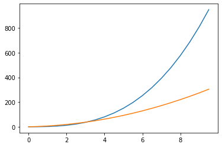

```python
plt.plot(X,Y)
plt.plot(X,Y1)
```

## Beda Hingga, untuk turunan tingkat tinggi?

Kita juga bisa menurunkan turunan yang lebih tinggi untuk menghitung turunan tinggi.

Seperti halnya turunan tingkat pertama, kita juga punya beda maju, beda mundur, dan beda tengah.

Untuk turunan tingkat kedua $f''(x)$, kita bisa menghitung beda maju sebagai berikut

$$ \begin{aligned} f''(x) &= \frac{f'(x+h) - f'(x)}{h} \\ &=\frac{\frac{f(x+2h) - f(x+h)}{h} - \frac{f(x+h) - f(x)}{h}}{h} \\ &=\frac{f(x+2h) - 2f(x+h) + f(x)}{h^2} \end{aligned} $$

## Beda Hingga untuk Turunan Tingkat Tinggi

Dengan cara yang sama, bisa diperoleh beda mundur dan beda tengah berturut-turut sebagai berikut.

$$ f''(x) =\frac{f(x) - 2f(x-h) + f(x-2h)}{h^2} $$

dan $$ f''(x) =\frac{f(x+h) - 2f(x) + f(x-h)}{h^2} $$

## Aplikasi

Selain seperti yang telah diceritakan di awal, yaitu menghitung cepat, beda hingga juga bisa digunakan untuk menyelesaikan persamaan diferensial secara numeris. Hasilnya cepat, namun tentu saja akurasinya tidak sebagus apabila menggunakan metode eksak.

Misalkan kita mempunyai suatu model persamaan $$ u'(x) = 2u(x) + 3 $$

Dengan beda maju, kita mempunyai perkiraan untuk $u'(x) = \frac{u(x+h) - u(x)}{h}$.

Dengan mensubstitusi nilai ini, kita dapatkan persamaan baru yaitu

$$ u(x+h) = u(x) + h (2u(x) +3).$$

Artinya, jika kita memiliki satu saja nilai awal dari persamaan tersebut. Maka kita bisa mendapatkan nilai berapapun yang kita inginkan.

> "Nature is written in mathematical language."

Galileo Galilei